# tr_results_2018

RSF

20 December 2018

# Age, time and the international correlation of cervical cancer

## 1. Update on the internation correlation of HPV and cervical cancer

#### 1.1 Data selection

##### Figure 1: Flow chart describing the data choice process for the update of the international correlation of high-risk HPV prevalence and cervical cancer incidence

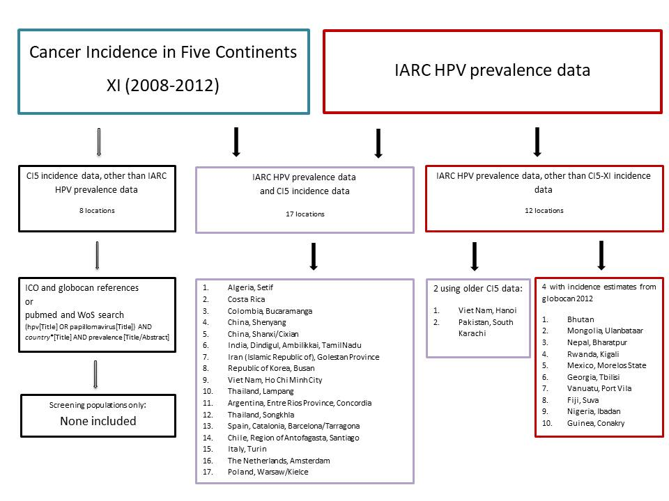

#### 1.2 Results

The strength of the international correlation between high-risk HPV prevalence and cervical cancer incidence rates was assessed using the Spearman rank correlation coefficient.

```r
for (i in levels(inc.prev.upd$age.grp)){
  spear$all[[str_c(i)]] <- cor.test(x = inc.prev.upd$prev[inc.prev.upd$age.grp == i],
                                    y = inc.prev.upd$IR[inc.prev.upd$age.grp == i],
                     alternative = "two.sided",
                     method = "spearman",
                     exact = FALSE)
  }
```

Then a linear Poisson regression model was fitted to the aggregate data in each age group using high-risk HPV prevalence in each centre. The regression model was fitted without an intercept term to satisfy the constraint that cervical cancer rates should be zero if the HPV prevalence is zero (Figure 2)

```r
inc.prev.upd$wt <- 100000

for(i in levels(inc.prev.upd$age.grp)) {
  upd.glm[[i]] <- glm(IR ~ prev -1, family = poisson(link = "identity"),
                    data = inc.prev.upd[inc.prev.upd$age.grp == i,], weights = wt)
  upd.coef[[i]] <- round(coef(upd.glm[[i]])[1], 2)
  upd.p[[i]] <- ifelse(coef(summary(upd.glm[[i]]))[,4] < 0.001, "<0.0001", ">0.0001" )
  }
```

##### Table 1: Most recent age-specific cervical cancer incidence and contemporary high-risk HPV prevalence

Prevalence and incidence by location and age group

| Location | Study year | Prevalence 25-34 (%) | Prevalence 35-44 (%) | Prevalence 45-54 (%) | Prevalence 55-64 (%) | Incidence source | Incidence 25-34 (/100.000) | Incidence 35-44 (/100.000) | Incidence 45-54 (/100.000) | Incidence 55-64 (/100.000) |
| --- | --- | --- | --- | --- | --- | --- | --- | --- | --- | --- |
| Algeria | 2007-2008 | 3.2 | 3.3 | 4.9 | 8.6 | CI5 | 1.0 | 7.0 | 18.0 | 22.4 |
| Argentina | 1998-1998 | 16.1 | 10.8 | 6.2 | 6.3 | CI5 | 16.5 | 29.6 | 39.9 | 32.5 |
| Bhutan | 2004-2008 | 18.9 | 14.3 | 11.2 | 7.3 | globocan 2018 | 6.4 | 21.2 | 47.6 | 46.1 |
| Chile | 2001-2003 | 8.1 | 7.0 | 6.5 | 8.3 | CI5 | 8.5 | 26.4 | 34.7 | 24.7 |
| China(Shanxi) | NA | 6.9 | 17.0 | 14.1 | 9.9 | CI5 | 1.1 | 12.2 | 26.8 | 50.8 |
| China(Shenyang) | 2005-2005 | 12.1 | 12.4 | 13.5 | 5.4 | CI5 | 5.8 | 25.8 | 36.7 | 21.6 |
| Colombia | 1993-1995 | 10.9 | 6.9 | 1.4 | 7.4 | CI5 | 10.7 | 28.5 | 28.5 | 26.3 |
| Costa Rica | 1993-1994 | 11.8 | 9.7 | 7.7 | 6.2 | CI5 | 17.0 | 28.3 | 27.6 | 23.9 |
| Fiji | 2003-2007 | 68.4 | 45.2 | 54.9 | 30.8 | globocan 2018 | 19.6 | 47.0 | 73.7 | 67.2 |
| Georgia | 2007-2007 | 12.2 | 4.8 | 6.2 | 3.6 | globocan 2018 | 6.5 | 17.8 | 27.5 | 26.5 |
| Guinea | 2006-2006 | 28.7 | 24.4 | 35.8 | 32.8 | globocan 2018 | 16.2 | 53.8 | 105.2 | 155.9 |
| India | 2004-2004 | 11.2 | 14.1 | 12.3 | 11.1 | CI5 | 3.5 | 26.8 | 65.8 | 72.3 |
| Iran | 2013-2014 | 4.8 | 4.0 | 6.2 | 3.4 | CI5 | 1.7 | 7.8 | 16.5 | 17.8 |
| Italy | 2002-2002 | 11.1 | 7.9 | 3.9 | 3.5 | CI5 | 5.0 | 9.1 | 12.3 | 12.0 |
| Mexico | 1996-1999 | 6.1 | 3.0 | 7.3 | 9.1 | globocan 2018 | 9.3 | 18.0 | 23.6 | 28.3 |
| Mongolia | 2005-2005 | 24.9 | 17.6 | 17.5 | 30.8 | globocan 2018 | 12.2 | 35.7 | 61.1 | 73.9 |
| Nepal | 2006-2007 | 5.4 | 8.0 | 5.6 | 3.1 | globocan 2018 | 11.4 | 40.4 | 67.6 | 67.8 |
| Netherlands | 1995-1998 | 8.3 | 2.0 | 2.3 | 1.4 | CI5 | 10.5 | 15.8 | 13.2 | 9.5 |
| Nigeria | 1999-1999 | 14.3 | 18.7 | 16.8 | 20.3 | globocan 2018 | 4.7 | 27.9 | 62.7 | 115.6 |
| Pakistan | 2004-2008 | 2.1 | 0.8 | 1.8 | 4.0 | NA | NA | NA | NA | NA |
| Poland | 2006-2006 | 18.3 | 11.4 | 6.3 | 3.2 | CI5 | 3.1 | 15.4 | 28.3 | 34.3 |
| Republic of Korea | 1999-2000 | 10.1 | 4.0 | 5.1 | 6.2 | CI5 | 11.3 | 22.6 | 27.3 | 25.4 |
| Rwanda | 2013-2014 | 21.2 | 14.3 | 13.0 | 9.6 | globocan 2018 | 13.0 | 40.3 | 76.5 | 108.5 |
| Spain | 1998-2000 | 1.9 | 1.7 | 0.6 | 0.0 | CI5 | 6.1 | 13.1 | 19.2 | 16.7 |
| Thailand (Lampang) | 1997-1998 | 7.7 | 7.9 | 5.3 | 5.2 | CI5 | 7.0 | 23.8 | 33.5 | 30.0 |
| Thailand (Songkla) | 1990-2000 | 4.5 | 0.0 | 2.3 | 0.7 | CI5 | 5.4 | 17.6 | 31.8 | 32.0 |
| Vanuatu | 2009-2011 | 20.9 | 18.1 | 9.3 | 30.8 | globocan 2018 | 28.9 | 32.9 | 41.4 | 41.4 |
| Viet Nam | 1997-1997 | 5.8 | 7.0 | 4.5 | 6.1 | CI5 | 2.5 | 15.2 | 31.0 | 54.7 |
| Viet Nam, Hanoi | 1997-1997 | 2.7 | 0.5 | 1.8 | 0.5 | CI5 | 1.9 | 12.9 | 18.9 | 17.5 |

##### Figure 2: International correlation between cervical cancer incidence and high-risk HPV prevalence by 10-year age group.

The estimated spearman rank coefficients (rho) and poisson coefficients (coef) are specified for the sccording age group. The black line represents the fitted Poisson model and the grey area the 95% confidence interval *(fitted by the ggplot machinerie)*.

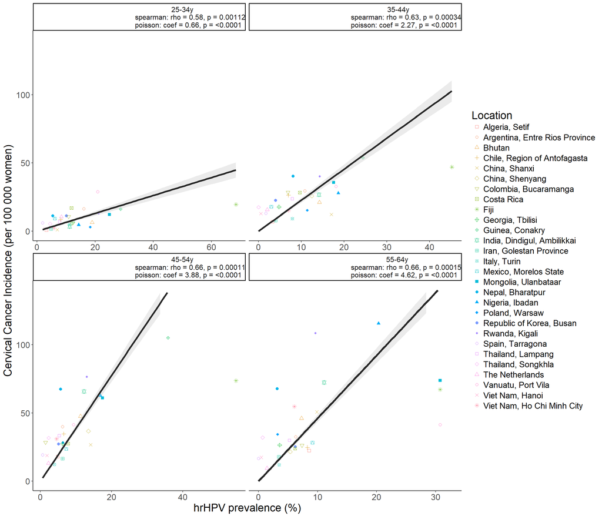

## 2. Ecological estimate of the transition rate from HPV to cervical cancer

#### 2.1 Methods

To estimate the transition rate from hrHPV infection to cervical cancer we followed the multistage model describing the natural history of cervical cancer, including death as competitive risk. This allowed us to evaluate the cervical cancer incidence rate in women tested HPV+ at a certain age in the year of the prevalence study in the respective country (Figure 3).

##### Figure 3: Competitive risk model describing the natural history of cervical cancer used to estimate the transition rate from high-risk HPV infection to cervical cancer

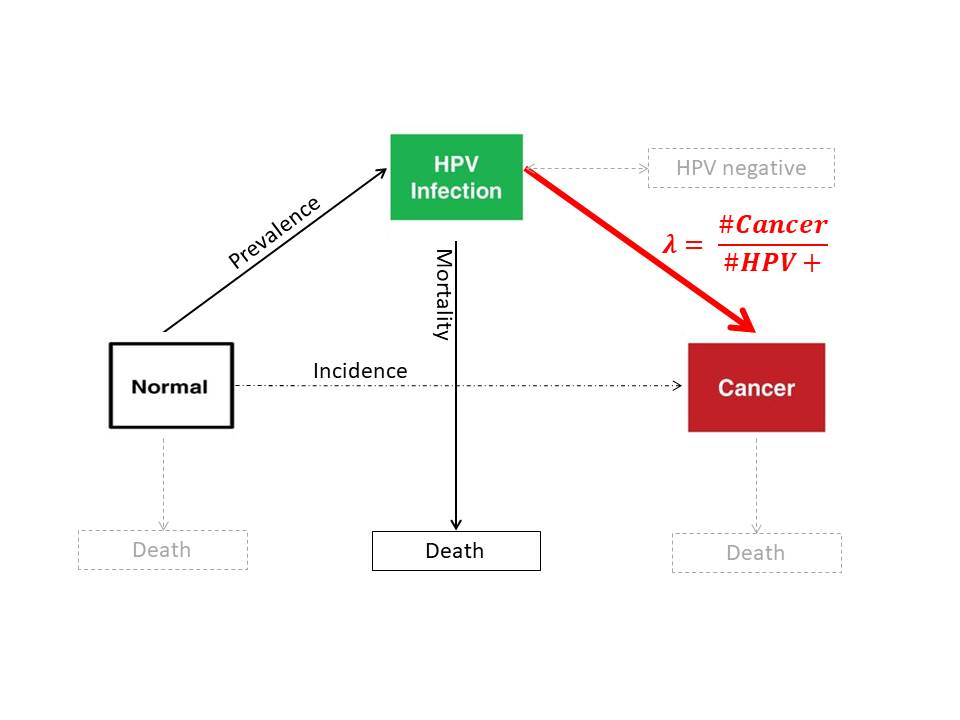

Multiplying the population and the prevalence in each age group and location yields the corresponding number of hrHPV+ women. We then used the UN population data and CI5 incidence and UN mortality rates to estimate the number of new cancer cases and deaths per year in each age group and location. Assuming that the HPV prevalence is constant in each 10-year age group, thus that new infections and clearance even out, we could then consider the transition rate being the number of new cancer cases in the remaining event free HPV+ population for each age group, year and location. We shifted the age groups by one year every calendar year to then apply the respective time and age-specific rates.

```r
DpC <- Dp %>%
  ungroup() %>%
  group_by(Year, YsncS, cid, Location, cov) %>%
  summarise(Npos = sum(Npos),
          Nicc = sum(Nicc),
          prev = sum(Npos)*100/sum(PopFemale),
          IR = sum(Nicc)*100000/sum(PopFemale), # incidence rate in whole population
          logIR = log(sum(Nicc)/sum(PopFemale)),
          se = sqrt(sum(Nicc))/sum(Npos), # standard error of rates = Rate^2/cases=sqrt(cases)/personyears
                                          # [Esteve p.52]
          tr = sum(Nicc)/sum(Npos), # transition rate
          log_tr = log(sum(Nicc)/sum(Npos)), # log transition rate
          selog = sqrt(1/sum(Npos))) %>% # var(log(k/m)) = 1/(Rate*pyears); se(log(k/m)) = sqrt(1/k) [Esteve p. 53]
  filter(Location != "Viet Nam")%>%
  filter(YsncS <= 14) %>% # > 15 years of follow up only Costa Rica and Colombia. < 14years: > 5 Locations
  mutate(ag = stringr::str_c(mina, "_", maxa))
```

We then fitted a latent class mixed model to describe the time trend of the transition rates since HPV detection, thus since the year of the equivalent HPV prevalence study. Single-class quadratic I-splines with a random effect on intercept and slope were selected the best fitting model through the Bayesian Information Criterion included in the lcmm package in R.

To explore the effect of screening we included high versus unclear screening coverage as covariate in the latent class mixed model. There was no significant difference neither for 10-year nor for 5-year age groups. However a significant effect of age on the transition rate and its time trend could be observed when fitting one lcmm model for all transition rates and adjusting for age.

```r
# adjusting for screening coverage
lcmm_out$tr_lcmm[[stringr::str_c(mina, "_", maxa)]] <-
      tr_lcmm <- lcmm(log_tr ~ YsncS * cov, random = ~ YsncS, subject = "Location",  ng = 1, data = DpC, link = "4-equi-splines")


# the effect of age on the time trand of the transition rate
tr_c <- lcmm(log_tr ~ YsncS * cov * ag, random = ~ YsncS, subject = "Location",  ng = 1,
             data = DpC_df, link = "4-equi-splines")

tr_1 <- lcmm(log_tr ~ YsncS* ag, random = ~ YsncS, subject = "Location",  ng = 1,
             data = DpC_df[DpC_df$cov == 1, ], link = "4-equi-splines")

tr_2<- lcmm(log_tr ~ YsncS* ag, random = ~ YsncS, subject = "Location",  ng = 1,
            data = DpC_df[DpC_df$cov == 2, ], link = "4-equi-splines")
```

The number of knots in the link function was fixed to a maximum of 4 to assure sufficient data points in each knot.

```r
# prediction

nd <- data.frame(YsncS = 0:14)

lcmm_out$tr_pred[[stringr::str_c(mina, "_", maxa, "_1")]] <-
      tr_pred_1 <- predictY(tr_lcmm_1, nd, methInteg = 1, draws = TRUE)

lcmm_out$tr_pred[[stringr::str_c(mina, "_", maxa, "_2")]] <-
      tr_pred_2 <- predictY(tr_lcmm_2, nd, methInteg = 1, draws = TRUE)
```

We then calculated the derivatives of the transition models in the two screening groups (Figure 6).

```r
#lambda

lcmm_out$tr_lambda[[stringr::str_c(mina, "_", maxa, "_1")]] <-
      tr_lambda_1 <- data.frame("YsncS" = tr_pred_1$times[2:15,]-0.5,
                              "lambda" = diff(tr_pred_1$pred[, 1]))
lcmm_out$tr_lambda[[stringr::str_c(mina, "_", maxa, "_2")]] <-
      tr_lambda_2 <- data.frame("YsncS" = tr_pred_2$times[2:15,]-0.5,
                              "lambda" = diff(tr_pred_2$pred[, 1]))
```

#### 2.2. Results

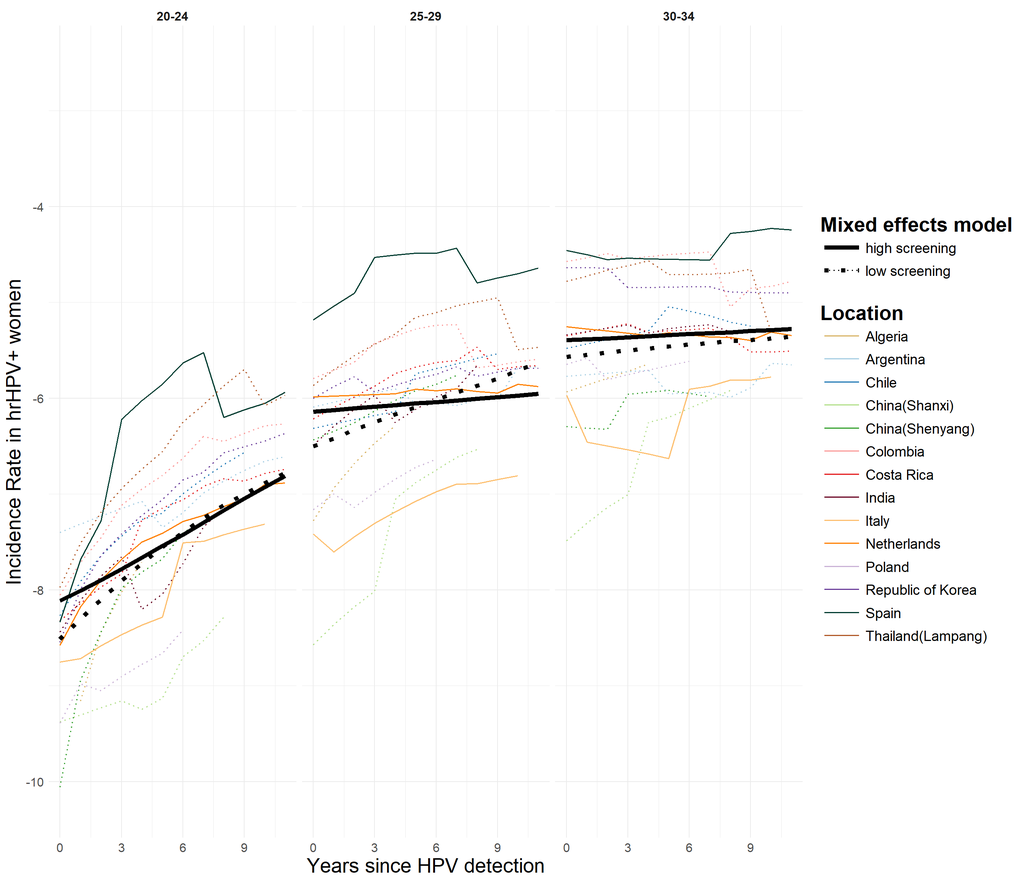

##### Figure 5: Transition rate over time since high-risk HPV detection to cervical cancer by age and screening coverage estimated using ecological data. Stratification in 5-year age groups.

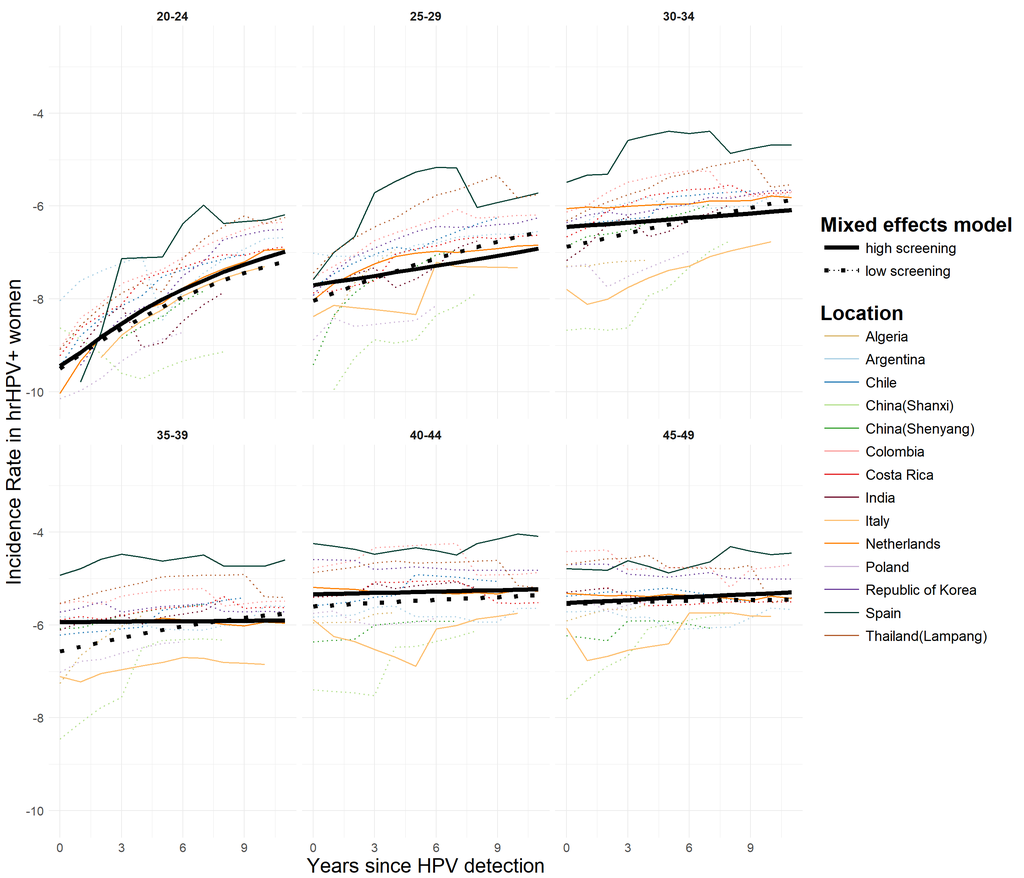

##### Figure 6: The change in cervical cancer transition rate over time since hpv detection by screening coverage

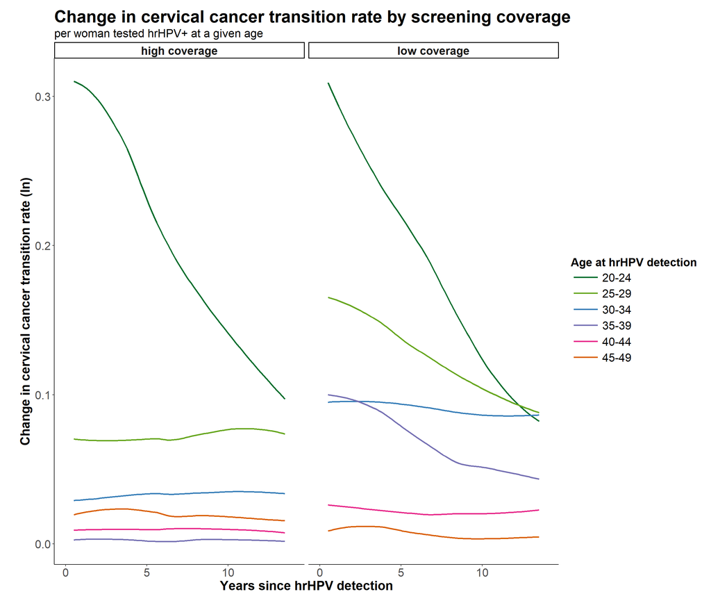